# Projeto de Capacidade Produtiva - Fase II

Allan B. Martins (CORED)

23 maio 2022

# 1 CORRELOGRAMA **2021** - **JAN A DEZ** - **GEO com escala invertida** - (**v4**)

## 1.1 Contextualização

Correlograma - Calcula a correlação de variáveis e exibe os resultados graficamente. As funções de painel incluídas podem exibir pontos, sombreamento, elipses e valores de correlação com intervalos de confiança nos ajudam a visualizar os dados em matrizes de correlação.

### 1.1.1 Etapa I - Estruturação do banco de dados para criação do correlograma

#### 1.1.1.1 Tabela de dados

| uf | zy_ubp_1000_hab | zy_rec_transf | zy_custo_ubp | zf_custeio_t | zf_ftp | zs_energ | zs_transp | zs_telecom | zs_snb | zs_econ | zs_segub | zs_geo_n | zs_estaber_capta |
| --- | --- | --- | --- | --- | --- | --- | --- | --- | --- | --- | --- | --- | --- |
| AC | 1.48 | 0.16 | 17.9 | 0.47 | 0.00 | 0.00 | 15.5 | 18.2 | 9.0 | 0.0 | 0.69 | 0 | 12.6 |
| AL | 9.46 | 2.45 | 8.2 | 1.61 | 8.41 | 56.80 | 73.1 | 7.1 | 26.7 | 9.6 | 2.56 | 100 | 20.5 |
| AM | 7.73 | 5.01 | 51.6 | 4.74 | 7.45 | 0.21 | 0.0 | 6.3 | 4.8 | 76.8 | 3.74 | 71 | 4.4 |
| AP | 0.00 | 0.00 | 55.9 | 0.47 | 0.12 | 1.98 | 6.5 | 29.5 | 34.2 | 7.3 | 0.00 | 47 | 8.1 |
| BA | 23.33 | 15.17 | 47.6 | 12.58 | 34.11 | 8.03 | 25.6 | 25.4 | 58.3 | 31.1 | 17.27 | 100 | 40.6 |
| CE | 12.05 | 11.04 | 76.1 | 10.04 | 19.79 | 10.02 | 35.9 | 16.2 | 61.1 | 18.1 | 11.96 | 100 | 39.6 |
| ES | 8.78 | 7.09 | 73.0 | 7.22 | 4.77 | 16.18 | 48.6 | 28.8 | 97.3 | 73.6 | 9.25 | 100 | 83.5 |
| GO | 6.76 | 6.40 | 57.1 | 4.58 | 15.72 | 10.98 | 23.8 | 11.6 | 30.9 | 42.1 | 11.99 | 100 | 72.1 |
| MA | 7.40 | 5.10 | 47.3 | 4.23 | 7.28 | 3.62 | 21.3 | 20.8 | 0.0 | 11.1 | 6.72 | 100 | 0.0 |
| MG | 47.19 | 31.90 | 37.4 | 20.66 | 21.30 | 13.12 | 31.4 | 12.6 | 92.5 | 71.8 | 16.24 | 100 | 72.1 |
| MS | 9.32 | 8.24 | 86.6 | 8.90 | 6.40 | 5.33 | 23.9 | 39.0 | 65.3 | 71.2 | 3.47 | 48 | 67.7 |
| MT | 18.14 | 12.47 | 34.2 | 7.55 | 9.81 | 1.06 | 9.8 | 29.3 | 22.3 | 54.4 | 3.71 | 83 | 80.9 |
| PA | 9.97 | 7.48 | 24.0 | 3.26 | 5.01 | 4.64 | 4.0 | 54.5 | 1.2 | 60.9 | 8.16 | 94 | 7.9 |
| PB | 17.97 | 4.75 | 2.2 | 2.04 | 5.59 | 4.85 | 51.5 | 3.2 | 68.3 | 13.9 | 2.31 | 100 | 34.3 |
| PE | 14.96 | 11.62 | 52.4 | 8.88 | 7.89 | 17.60 | 53.5 | 6.0 | 78.9 | 27.6 | 15.79 | 100 | 21.6 |
| PI | 3.62 | 3.67 | 70.2 | 3.23 | 6.66 | 2.02 | 22.9 | 6.5 | 4.5 | 7.8 | 5.30 | 100 | 37.8 |
| PR | 27.48 | 24.85 | 69.8 | 20.43 | 22.58 | 39.75 | 44.7 | 11.8 | 50.4 | 93.8 | 16.51 | 67 | 94.2 |
| RJ | 34.39 | 29.52 | 68.2 | 24.88 | 42.37 | 100.00 | 100.0 | 70.5 | 94.3 | 98.3 | 38.42 | 100 | 59.5 |
| RN | 4.10 | 3.01 | 56.2 | 2.93 | 7.45 | 24.81 | 65.3 | 0.0 | 40.7 | 25.8 | 4.19 | 100 | 34.1 |
| RO | 3.61 | 3.21 | 13.1 | 0.82 | 3.26 | 9.30 | 17.1 | 9.4 | 2.8 | 31.7 | 2.87 | 44 | 37.8 |
| RR | 0.87 | 0.12 | 0.0 | 0.00 | 1.51 | 0.38 | 10.6 | 6.6 | 29.8 | 5.0 | 0.46 | 10 | 14.5 |
| RS | 15.97 | 18.07 | 41.8 | 7.84 | 12.22 | 14.18 | 45.7 | 24.8 | 28.1 | 84.0 | 14.91 | 51 | 87.9 |
| SC | 27.17 | 17.78 | 36.4 | 11.76 | 19.21 | 25.77 | 56.7 | 17.3 | 36.4 | 100.0 | 7.81 | 77 | 100.0 |
| SE | 6.46 | 2.22 | 30.0 | 2.57 | 6.14 | 72.49 | 32.5 | 48.9 | 41.0 | 26.5 | 2.23 | 100 | 16.7 |
| SP | 100.00 | 100.00 | 100.0 | 100.00 | 100.00 | 44.47 | 9.8 | 100.0 | 100.0 | 87.5 | 100.00 | 100 | 78.6 |
| TO | 2.68 | 1.65 | 50.4 | 1.88 | 6.05 | 2.97 | 14.4 | 11.6 | 8.3 | 17.7 | 1.16 | 100 | 52.3 |

### 1.1.2 Etapa II - Criação do Gráfico de Correlação entre indicadores e as variáveis

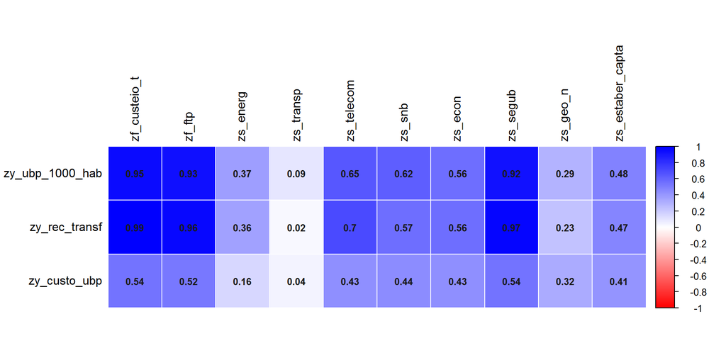

### 1.1.3 Etapa VI - VIF das variáveis estruturantes

# Contextualização

O banco de dados analisado traz os dados das variáveis estruturantes que são **zs_energ**, **zs_transp**,**zs_telecom**,**zs_snb**,**zs_econ**,**zs_segub**,**zs_geo_n**, e **zs_estaber_capta**. Por meio das técnicas de **Correlação, variância e covariância (matrizes)** e **Fatores de variação de inflação**, para se identificar as melhores variáveis para a etapa II do projeto capacidade produtiva.

# 2 Correlação, variância e covariância (matrizes)

## 2.1 Correlograma

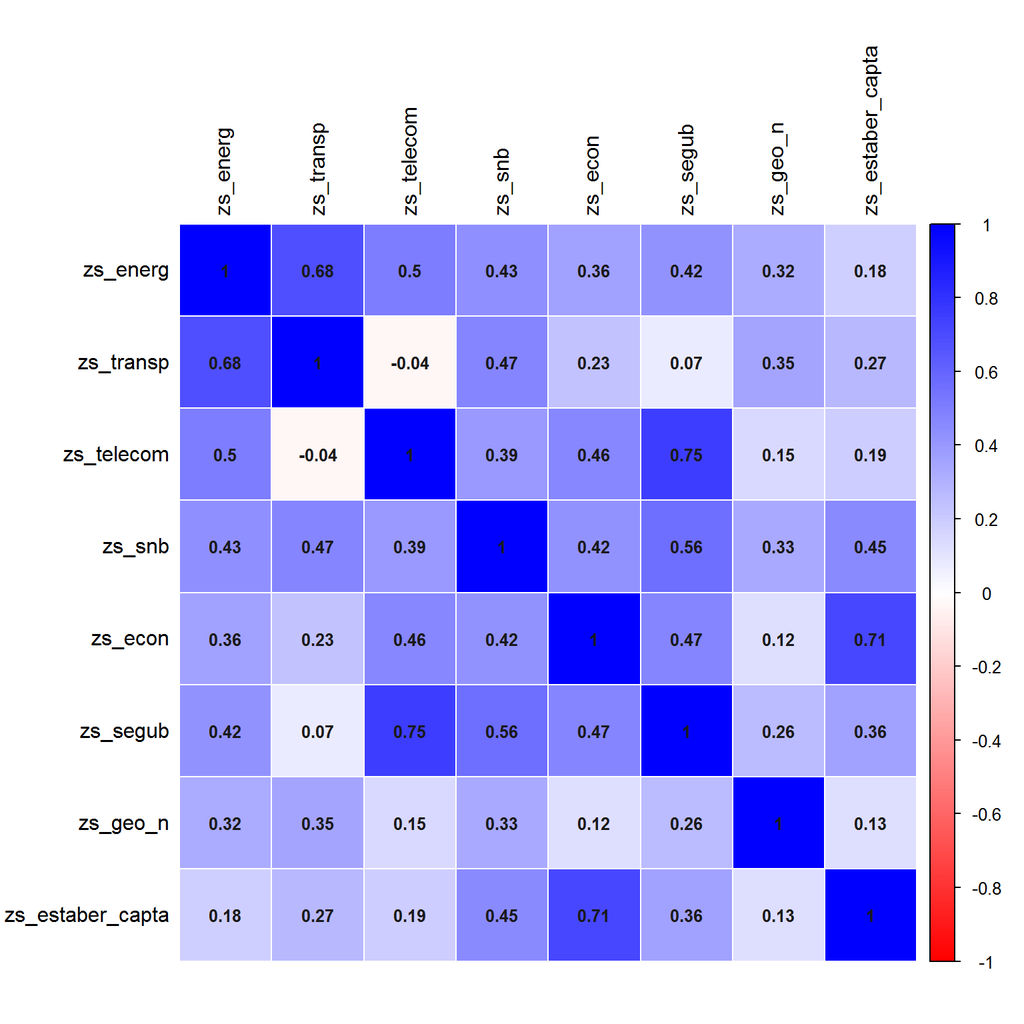

# 3 Fatores de variação de inflação

|  | vif.bd_temp1. |
| --- | --- |
| zs_energ | 4.2 |
| zs_transp | 4.2 |
| zs_telecom | 3.9 |
| zs_snb | 2.2 |
| zs_econ | 2.6 |
| zs_segub | 3.0 |
| zs_geo_n | 1.2 |
| zs_estaber_capta | 2.5 |

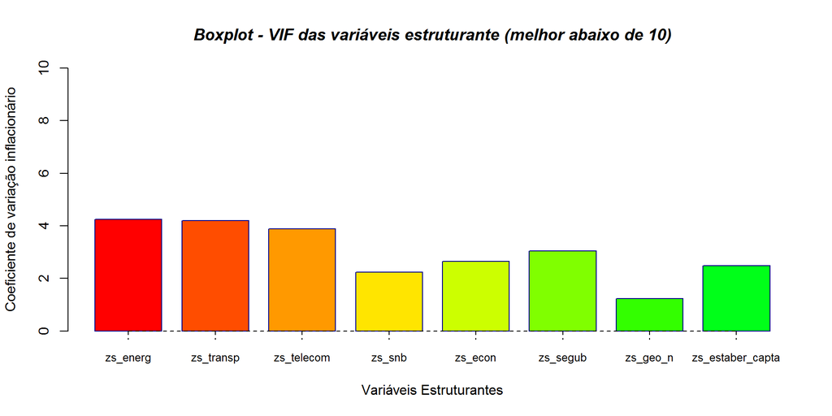

# 4 Diversos

## 4.2 Material de Apoio

- Visualização de Dados no R - ggpairs (pacote GGally):[]https://youtu.be/24c2GzxnrBI
- Correlação linear bivariada no R:[]https://youtu.be/7UGWOHF8k0Q
- Tutorial R | Fazer gráficos com ggplot2 - gráfico base, rain cloud e smooth regression:[]https://youtu.be/fXz_dsz_Jn4
- Multivariate Data Analyses:[]https://rpkgs.datanovia.com/factoextra/index.html
- A Metodologia PCA: []https://operdata.com.br/blog/analise-de-componentes-principais/
- PCA análise de componentes principais acp ou pca:[]https://youtu.be/hmp9KIPb5Ig
- PCA dúvidas e sugestões sobre análise de componentes principais:[]https://youtu.be/ATXoqEtNtdg
- PLAYLIST - R na Pesquisa Contábil (Parte 1 ao 20):[]https://youtube.com/playlist?list=PLF3Sjk1EY74ZcUWHE6ZDPHFRu9zp_20gD
- PLAYLIST - Criando gráficos no R com o ggplot2 (Parte 1 ao 2): [Fernanda Peres]https://youtu.be/DYsPRa3vpf0
- PLAYLIST - R Markdown: Gerando relatórios usando o R (Parte 1 ao 5): [Fernanda Peres]https://youtu.be/obxa5VH4WvY
- Minicurso R - UFPR: [UFPR]https://youtu.be/obxa5VH4WvY
- R Markdown: The Definitive Guide: [Yihui Xie, J. J. Allaire, Garrett Grolemund]https://bookdown.org/yihui/rmarkdown/
- Documentos dinâmicos no R []http://cursos.leg.ufpr.br/prr/capDocDin.html